# Optimal Treatment Analysis

## Outcome Variable

**Outcome Variable:** haz

## Predictor Variables

**Intervention Variable:** predfeed36

**Adjustment Set:**

- arm
- sex
- month
- brthmon
- W_mage
- meducyrs
- feducyrs
- hhwealth_quart
- hfoodsec
- W_mhtcm
- W_mwtkg
- W_mbmi
- vagbrth
- W_gagebrth
- W_birthwt
- W_birthlen
- W_nrooms
- W_nchldlt5
- W_parity
- impfloor
- impsan
- safeh20
- delta_W_mage
- delta_meducyrs
- delta_feducyrs
- delta_hhwealth_quart
- delta_hfoodsec
- delta_W_mhtcm
- delta_W_mwtkg
- delta_W_mbmi
- delta_vagbrth
- delta_W_gagebrth
- delta_W_birthwt
- delta_W_birthlen
- delta_W_nrooms
- delta_W_nchldlt5
- delta_W_parity
- delta_impfloor
- delta_impsan
- delta_safeh20

## Stratifying Variables

The analysis was stratified on these variable(s):

- agecat
- studyid
- country

## Data Summary

| agecat | studyid | country | predfeed36 | n_cell | n |
| --- | --- | --- | --- | --- | --- |
| Birth | ki0047075b-MAL-ED | BANGLADESH | 1 | 72 | 221 |
| Birth | ki0047075b-MAL-ED | BANGLADESH | 0 | 149 | 221 |
| Birth | ki0047075b-MAL-ED | BRAZIL | 1 | 8 | 65 |
| Birth | ki0047075b-MAL-ED | BRAZIL | 0 | 57 | 65 |
| Birth | ki0047075b-MAL-ED | INDIA | 1 | 4 | 42 |
| Birth | ki0047075b-MAL-ED | INDIA | 0 | 38 | 42 |
| Birth | ki0047075b-MAL-ED | NEPAL | 1 | 1 | 26 |
| Birth | ki0047075b-MAL-ED | NEPAL | 0 | 25 | 26 |
| Birth | ki0047075b-MAL-ED | PERU | 1 | 58 | 223 |
| Birth | ki0047075b-MAL-ED | PERU | 0 | 165 | 223 |
| Birth | ki0047075b-MAL-ED | SOUTH AFRICA | 1 | 2 | 105 |
| Birth | ki0047075b-MAL-ED | SOUTH AFRICA | 0 | 103 | 105 |
| Birth | ki0047075b-MAL-ED | TANZANIA, UNITED REPUBLIC OF | 1 | 0 | 119 |
| Birth | ki0047075b-MAL-ED | TANZANIA, UNITED REPUBLIC OF | 0 | 119 | 119 |
| Birth | ki1000109-EE | PAKISTAN | 1 | 3 | 7 |
| Birth | ki1000109-EE | PAKISTAN | 0 | 4 | 7 |
| Birth | ki1113344-GMS-Nepal | NEPAL | 1 | 422 | 526 |
| Birth | ki1113344-GMS-Nepal | NEPAL | 0 | 104 | 526 |
| Birth | kiGH5241-JiVitA-3 | BANGLADESH | 1 | 9859 | 12642 |
| Birth | kiGH5241-JiVitA-3 | BANGLADESH | 0 | 2783 | 12642 |
| Birth | kiGH5241-JiVitA-4 | BANGLADESH | 1 | 1999 | 2517 |
| Birth | kiGH5241-JiVitA-4 | BANGLADESH | 0 | 518 | 2517 |
| 6 months | ki0047075b-MAL-ED | BANGLADESH | 1 | 81 | 240 |
| 6 months | ki0047075b-MAL-ED | BANGLADESH | 0 | 159 | 240 |
| 6 months | ki0047075b-MAL-ED | BRAZIL | 1 | 25 | 209 |
| 6 months | ki0047075b-MAL-ED | BRAZIL | 0 | 184 | 209 |
| 6 months | ki0047075b-MAL-ED | INDIA | 1 | 17 | 233 |
| 6 months | ki0047075b-MAL-ED | INDIA | 0 | 216 | 233 |
| 6 months | ki0047075b-MAL-ED | NEPAL | 1 | 8 | 235 |
| 6 months | ki0047075b-MAL-ED | NEPAL | 0 | 227 | 235 |
| 6 months | ki0047075b-MAL-ED | PERU | 1 | 72 | 272 |
| 6 months | ki0047075b-MAL-ED | PERU | 0 | 200 | 272 |
| 6 months | ki0047075b-MAL-ED | SOUTH AFRICA | 1 | 3 | 250 |
| 6 months | ki0047075b-MAL-ED | SOUTH AFRICA | 0 | 247 | 250 |
| 6 months | ki0047075b-MAL-ED | TANZANIA, UNITED REPUBLIC OF | 1 | 5 | 243 |
| 6 months | ki0047075b-MAL-ED | TANZANIA, UNITED REPUBLIC OF | 0 | 238 | 243 |
| 6 months | ki1000109-EE | PAKISTAN | 1 | 4 | 9 |
| 6 months | ki1000109-EE | PAKISTAN | 0 | 5 | 9 |
| 6 months | ki1000304b-SAS-FoodSuppl | INDIA | 1 | 0 | 168 |
| 6 months | ki1000304b-SAS-FoodSuppl | INDIA | 0 | 168 | 168 |
| 6 months | ki1113344-GMS-Nepal | NEPAL | 1 | 422 | 527 |
| 6 months | ki1113344-GMS-Nepal | NEPAL | 0 | 105 | 527 |
| 6 months | ki1148112-LCNI-5 | MALAWI | 1 | 47 | 272 |
| 6 months | ki1148112-LCNI-5 | MALAWI | 0 | 225 | 272 |
| 6 months | kiGH5241-JiVitA-3 | BANGLADESH | 1 | 6576 | 8533 |
| 6 months | kiGH5241-JiVitA-3 | BANGLADESH | 0 | 1957 | 8533 |
| 6 months | kiGH5241-JiVitA-4 | BANGLADESH | 1 | 3253 | 4185 |
| 6 months | kiGH5241-JiVitA-4 | BANGLADESH | 0 | 932 | 4185 |
| 24 months | ki0047075b-MAL-ED | BANGLADESH | 1 | 69 | 212 |
| 24 months | ki0047075b-MAL-ED | BANGLADESH | 0 | 143 | 212 |
| 24 months | ki0047075b-MAL-ED | BRAZIL | 1 | 20 | 169 |
| 24 months | ki0047075b-MAL-ED | BRAZIL | 0 | 149 | 169 |
| 24 months | ki0047075b-MAL-ED | INDIA | 1 | 17 | 224 |
| 24 months | ki0047075b-MAL-ED | INDIA | 0 | 207 | 224 |
| 24 months | ki0047075b-MAL-ED | NEPAL | 1 | 8 | 227 |
| 24 months | ki0047075b-MAL-ED | NEPAL | 0 | 219 | 227 |
| 24 months | ki0047075b-MAL-ED | PERU | 1 | 53 | 201 |
| 24 months | ki0047075b-MAL-ED | PERU | 0 | 148 | 201 |
| 24 months | ki0047075b-MAL-ED | SOUTH AFRICA | 1 | 3 | 235 |
| 24 months | ki0047075b-MAL-ED | SOUTH AFRICA | 0 | 232 | 235 |
| 24 months | ki0047075b-MAL-ED | TANZANIA, UNITED REPUBLIC OF | 1 | 4 | 213 |
| 24 months | ki0047075b-MAL-ED | TANZANIA, UNITED REPUBLIC OF | 0 | 209 | 213 |
| 24 months | ki1000109-EE | PAKISTAN | 1 | 0 | 3 |
| 24 months | ki1000109-EE | PAKISTAN | 0 | 3 | 3 |
| 24 months | ki1113344-GMS-Nepal | NEPAL | 1 | 363 | 446 |
| 24 months | ki1113344-GMS-Nepal | NEPAL | 0 | 83 | 446 |
| 24 months | ki1148112-LCNI-5 | MALAWI | 1 | 34 | 189 |
| 24 months | ki1148112-LCNI-5 | MALAWI | 0 | 155 | 189 |
| 24 months | kiGH5241-JiVitA-3 | BANGLADESH | 1 | 3311 | 4300 |
| 24 months | kiGH5241-JiVitA-3 | BANGLADESH | 0 | 989 | 4300 |
| 24 months | kiGH5241-JiVitA-4 | BANGLADESH | 1 | 3157 | 4049 |
| 24 months | kiGH5241-JiVitA-4 | BANGLADESH | 0 | 892 | 4049 |

The following strata were considered:

- agecat: 24 months, studyid: ki0047075b-MAL-ED, country: BANGLADESH
- agecat: 24 months, studyid: ki0047075b-MAL-ED, country: BRAZIL
- agecat: 24 months, studyid: ki0047075b-MAL-ED, country: INDIA
- agecat: 24 months, studyid: ki0047075b-MAL-ED, country: NEPAL
- agecat: 24 months, studyid: ki0047075b-MAL-ED, country: PERU
- agecat: 24 months, studyid: ki0047075b-MAL-ED, country: SOUTH AFRICA
- agecat: 24 months, studyid: ki0047075b-MAL-ED, country: TANZANIA, UNITED REPUBLIC OF
- agecat: 24 months, studyid: ki1000109-EE, country: PAKISTAN
- agecat: 24 months, studyid: ki1113344-GMS-Nepal, country: NEPAL
- agecat: 24 months, studyid: ki1148112-LCNI-5, country: MALAWI
- agecat: 24 months, studyid: kiGH5241-JiVitA-3, country: BANGLADESH
- agecat: 24 months, studyid: kiGH5241-JiVitA-4, country: BANGLADESH
- agecat: 6 months, studyid: ki0047075b-MAL-ED, country: BANGLADESH
- agecat: 6 months, studyid: ki0047075b-MAL-ED, country: BRAZIL
- agecat: 6 months, studyid: ki0047075b-MAL-ED, country: INDIA
- agecat: 6 months, studyid: ki0047075b-MAL-ED, country: NEPAL
- agecat: 6 months, studyid: ki0047075b-MAL-ED, country: PERU
- agecat: 6 months, studyid: ki0047075b-MAL-ED, country: SOUTH AFRICA
- agecat: 6 months, studyid: ki0047075b-MAL-ED, country: TANZANIA, UNITED REPUBLIC OF
- agecat: 6 months, studyid: ki1000109-EE, country: PAKISTAN
- agecat: 6 months, studyid: ki1000304b-SAS-FoodSuppl, country: INDIA
- agecat: 6 months, studyid: ki1113344-GMS-Nepal, country: NEPAL
- agecat: 6 months, studyid: ki1148112-LCNI-5, country: MALAWI
- agecat: 6 months, studyid: kiGH5241-JiVitA-3, country: BANGLADESH
- agecat: 6 months, studyid: kiGH5241-JiVitA-4, country: BANGLADESH
- agecat: Birth, studyid: ki0047075b-MAL-ED, country: BANGLADESH
- agecat: Birth, studyid: ki0047075b-MAL-ED, country: BRAZIL
- agecat: Birth, studyid: ki0047075b-MAL-ED, country: INDIA
- agecat: Birth, studyid: ki0047075b-MAL-ED, country: NEPAL
- agecat: Birth, studyid: ki0047075b-MAL-ED, country: PERU
- agecat: Birth, studyid: ki0047075b-MAL-ED, country: SOUTH AFRICA
- agecat: Birth, studyid: ki0047075b-MAL-ED, country: TANZANIA, UNITED REPUBLIC OF
- agecat: Birth, studyid: ki1000109-EE, country: PAKISTAN
- agecat: Birth, studyid: ki1113344-GMS-Nepal, country: NEPAL
- agecat: Birth, studyid: kiGH5241-JiVitA-3, country: BANGLADESH
- agecat: Birth, studyid: kiGH5241-JiVitA-4, country: BANGLADESH

### Dropped Strata

Some strata were dropped due to rare outcomes:

- agecat: Birth, studyid: ki0047075b-MAL-ED, country: INDIA
- agecat: Birth, studyid: ki0047075b-MAL-ED, country: NEPAL
- agecat: Birth, studyid: ki0047075b-MAL-ED, country: SOUTH AFRICA
- agecat: Birth, studyid: ki0047075b-MAL-ED, country: TANZANIA, UNITED REPUBLIC OF
- agecat: Birth, studyid: ki1000109-EE, country: PAKISTAN
- agecat: 6 months, studyid: ki0047075b-MAL-ED, country: SOUTH AFRICA
- agecat: 6 months, studyid: ki1000109-EE, country: PAKISTAN
- agecat: 6 months, studyid: ki1000304b-SAS-FoodSuppl, country: INDIA
- agecat: 24 months, studyid: ki0047075b-MAL-ED, country: SOUTH AFRICA
- agecat: 24 months, studyid: ki0047075b-MAL-ED, country: TANZANIA, UNITED REPUBLIC OF
- agecat: 24 months, studyid: ki1000109-EE, country: PAKISTAN

## Methods Detail

We’re interested in the causal parameters $E[Y_a]$ for all values of $a \in \mathcal{A}$. These parameters represent the mean outcome if, possibly contrary to fact, we intervened to set all units to have $A=a$. Under the randomization and positivity assumptions, these are identified by the statistical parameters $\psi_a=E_W[E_{Y|A,W}(Y|A=a,W)]$. In addition, we’re interested in the mean of $Y$, $E[Y]$ under no intervention (the observed mean). We will estimate these parameters by using SuperLearner to fit the relevant likelihood factors – $E_{Y|A,W}(Y|A=a,W)$ and $p(A=a|W)$, and then updating our likelihood fit using a joint TMLE.

For unadjusted analyses ($W=\{\}$), initial likelihoods were estimated using Lrnr_glm to estimate the simple $E(Y|A)$ and Lrnr_mean to estimate $p(A)$. For adjusted analyses, a small library containing Lrnr_glmnet, Lrnr_xgboost, and Lrnr_mean was used.

Having estimated these parameters, we will then use the delta method to estimate relative risks and attributable risks relative to a prespecified baseline level of $A$.

# Results Detail

## Results Plots

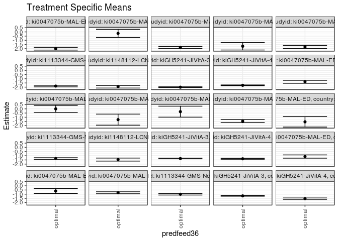

## Results Table

### Parameter: TSM

| agecat | studyid | country | intervention_level | baseline_level | estimate | ci_lower | ci_upper |
| --- | --- | --- | --- | --- | --- | --- | --- |
| Birth | ki0047075b-MAL-ED | BANGLADESH | optimal | observed | -1.0983118 | -1.2946008 | -0.9020228 |
| Birth | ki0047075b-MAL-ED | BRAZIL | optimal | observed | -0.6203068 | -0.9114356 | -0.3291780 |
| Birth | ki0047075b-MAL-ED | PERU | optimal | observed | -0.8306558 | -0.9486780 | -0.7126335 |
| Birth | ki1113344-GMS-Nepal | NEPAL | optimal | observed | -1.0054646 | -1.1014296 | -0.9094995 |
| Birth | kiGH5241-JiVitA-3 | BANGLADESH | optimal | observed | -1.2009113 | -1.2405092 | -1.1613135 |
| Birth | kiGH5241-JiVitA-4 | BANGLADESH | optimal | observed | -1.5277735 | -1.6083833 | -1.4471636 |
| 6 months | ki0047075b-MAL-ED | BANGLADESH | optimal | observed | -1.3637960 | -1.5419086 | -1.1856835 |
| 6 months | ki0047075b-MAL-ED | BRAZIL | optimal | observed | -0.0008582 | -0.4251389 | 0.4234225 |
| 6 months | ki0047075b-MAL-ED | INDIA | optimal | observed | -1.2855568 | -1.9435028 | -0.6276109 |
| 6 months | ki0047075b-MAL-ED | NEPAL | optimal | observed | -0.3334153 | -0.9894781 | 0.3226475 |
| 6 months | ki0047075b-MAL-ED | PERU | optimal | observed | -1.4636230 | -1.6473307 | -1.2799154 |
| 6 months | ki0047075b-MAL-ED | TANZANIA, UNITED REPUBLIC OF | optimal | observed | -1.5484768 | -2.1695987 | -0.9273550 |
| 6 months | ki1113344-GMS-Nepal | NEPAL | optimal | observed | -1.3358282 | -1.4319078 | -1.2397486 |
| 6 months | ki1148112-LCNI-5 | MALAWI | optimal | observed | -1.4601992 | -1.6399115 | -1.2804870 |
| 6 months | kiGH5241-JiVitA-3 | BANGLADESH | optimal | observed | -1.3364459 | -1.3744115 | -1.2984803 |
| 6 months | kiGH5241-JiVitA-4 | BANGLADESH | optimal | observed | -1.3649214 | -1.4212504 | -1.3085924 |
| 24 months | ki0047075b-MAL-ED | BANGLADESH | optimal | observed | -2.0019932 | -2.1656993 | -1.8382870 |
| 24 months | ki0047075b-MAL-ED | BRAZIL | optimal | observed | -0.1758255 | -0.6647210 | 0.3130699 |
| 24 months | ki0047075b-MAL-ED | INDIA | optimal | observed | -1.8613994 | -1.9913211 | -1.7314777 |
| 24 months | ki0047075b-MAL-ED | NEPAL | optimal | observed | -1.7099503 | -2.1561273 | -1.2637733 |
| 24 months | ki0047075b-MAL-ED | PERU | optimal | observed | -1.7952757 | -1.9788725 | -1.6116789 |
| 24 months | ki1113344-GMS-Nepal | NEPAL | optimal | observed | -1.8711512 | -1.9649054 | -1.7773969 |
| 24 months | ki1148112-LCNI-5 | MALAWI | optimal | observed | -1.9503377 | -2.1086369 | -1.7920384 |
| 24 months | kiGH5241-JiVitA-3 | BANGLADESH | optimal | observed | -2.0034869 | -2.0459623 | -1.9610116 |
| 24 months | kiGH5241-JiVitA-4 | BANGLADESH | optimal | observed | -1.7811205 | -1.8251056 | -1.7371354 |

### Parameter: E(Y)

| agecat | studyid | country | intervention_level | baseline_level | estimate | ci_lower | ci_upper |
| --- | --- | --- | --- | --- | --- | --- | --- |
| Birth | ki0047075b-MAL-ED | BANGLADESH | observed | observed | -1.0802262 | -1.2151319 | -0.9453206 |
| Birth | ki0047075b-MAL-ED | BRAZIL | observed | observed | -0.6760000 | -0.9521457 | -0.3998543 |
| Birth | ki0047075b-MAL-ED | PERU | observed | observed | -0.8913004 | -1.0115814 | -0.7710195 |
| Birth | ki1113344-GMS-Nepal | NEPAL | observed | observed | -1.0299620 | -1.1192344 | -0.9406896 |
| Birth | kiGH5241-JiVitA-3 | BANGLADESH | observed | observed | -1.1758733 | -1.2120647 | -1.1396819 |
| Birth | kiGH5241-JiVitA-4 | BANGLADESH | observed | observed | -1.5234724 | -1.5733491 | -1.4735957 |
| 6 months | ki0047075b-MAL-ED | BANGLADESH | observed | observed | -1.2077639 | -1.3255735 | -1.0899543 |
| 6 months | ki0047075b-MAL-ED | BRAZIL | observed | observed | 0.0510207 | -0.0930194 | 0.1950608 |
| 6 months | ki0047075b-MAL-ED | INDIA | observed | observed | -1.2054220 | -1.3250470 | -1.0857970 |
| 6 months | ki0047075b-MAL-ED | NEPAL | observed | observed | -0.5616170 | -0.6748246 | -0.4484095 |
| 6 months | ki0047075b-MAL-ED | PERU | observed | observed | -1.3275368 | -1.4361710 | -1.2189025 |
| 6 months | ki0047075b-MAL-ED | TANZANIA, UNITED REPUBLIC OF | observed | observed | -1.3737037 | -1.4970489 | -1.2503585 |
| 6 months | ki1113344-GMS-Nepal | NEPAL | observed | observed | -1.3337634 | -1.4135810 | -1.2539459 |
| 6 months | ki1148112-LCNI-5 | MALAWI | observed | observed | -1.6395956 | -1.7592633 | -1.5199278 |
| 6 months | kiGH5241-JiVitA-3 | BANGLADESH | observed | observed | -1.3384308 | -1.3675493 | -1.3093123 |
| 6 months | kiGH5241-JiVitA-4 | BANGLADESH | observed | observed | -1.3514886 | -1.3904044 | -1.3125729 |
| 24 months | ki0047075b-MAL-ED | BANGLADESH | observed | observed | -1.9789151 | -2.1055330 | -1.8522972 |
| 24 months | ki0047075b-MAL-ED | BRAZIL | observed | observed | 0.0071006 | -0.1615817 | 0.1757828 |
| 24 months | ki0047075b-MAL-ED | INDIA | observed | observed | -1.8892634 | -2.0152690 | -1.7632578 |
| 24 months | ki0047075b-MAL-ED | NEPAL | observed | observed | -1.3125330 | -1.4327032 | -1.1923629 |
| 24 months | ki0047075b-MAL-ED | PERU | observed | observed | -1.7544776 | -1.8753255 | -1.6336298 |
| 24 months | ki1113344-GMS-Nepal | NEPAL | observed | observed | -1.8830717 | -1.9710591 | -1.7950844 |
| 24 months | ki1148112-LCNI-5 | MALAWI | observed | observed | -1.9651323 | -2.1053230 | -1.8249415 |
| 24 months | kiGH5241-JiVitA-3 | BANGLADESH | observed | observed | -2.0131814 | -2.0513347 | -1.9750280 |
| 24 months | kiGH5241-JiVitA-4 | BANGLADESH | observed | observed | -1.7922845 | -1.8313538 | -1.7532153 |

### Parameter: PAR

| agecat | studyid | country | intervention_level | baseline_level | estimate | ci_lower | ci_upper |
| --- | --- | --- | --- | --- | --- | --- | --- |
| Birth | ki0047075b-MAL-ED | BANGLADESH | optimal | observed | 0.0180855 | -0.1338528 | 0.1700239 |
| Birth | ki0047075b-MAL-ED | BRAZIL | optimal | observed | -0.0556932 | -0.1722468 | 0.0608604 |
| Birth | ki0047075b-MAL-ED | PERU | optimal | observed | -0.0606447 | -0.1349078 | 0.0136184 |
| Birth | ki1113344-GMS-Nepal | NEPAL | optimal | observed | -0.0244974 | -0.0663752 | 0.0173803 |
| Birth | kiGH5241-JiVitA-3 | BANGLADESH | optimal | observed | 0.0250380 | 0.0027464 | 0.0473297 |
| Birth | kiGH5241-JiVitA-4 | BANGLADESH | optimal | observed | 0.0043011 | -0.0534981 | 0.0621003 |
| 6 months | ki0047075b-MAL-ED | BANGLADESH | optimal | observed | 0.1560322 | 0.0366870 | 0.2753773 |
| 6 months | ki0047075b-MAL-ED | BRAZIL | optimal | observed | 0.0518789 | -0.3425206 | 0.4462784 |
| 6 months | ki0047075b-MAL-ED | INDIA | optimal | observed | 0.0801348 | -0.5431450 | 0.7034146 |
| 6 months | ki0047075b-MAL-ED | NEPAL | optimal | observed | -0.2282017 | -0.8735668 | 0.4171633 |
| 6 months | ki0047075b-MAL-ED | PERU | optimal | observed | 0.1360863 | -0.0201606 | 0.2923332 |
| 6 months | ki0047075b-MAL-ED | TANZANIA, UNITED REPUBLIC OF | optimal | observed | 0.1747731 | -0.4441294 | 0.7936757 |
| 6 months | ki1113344-GMS-Nepal | NEPAL | optimal | observed | 0.0020647 | -0.0592156 | 0.0633451 |
| 6 months | ki1148112-LCNI-5 | MALAWI | optimal | observed | -0.1793963 | -0.3197977 | -0.0389950 |
| 6 months | kiGH5241-JiVitA-3 | BANGLADESH | optimal | observed | -0.0019849 | -0.0255787 | 0.0216089 |
| 6 months | kiGH5241-JiVitA-4 | BANGLADESH | optimal | observed | 0.0134327 | -0.0285725 | 0.0554380 |
| 24 months | ki0047075b-MAL-ED | BANGLADESH | optimal | observed | 0.0230781 | -0.0935217 | 0.1396778 |
| 24 months | ki0047075b-MAL-ED | BRAZIL | optimal | observed | 0.1829261 | -0.2789555 | 0.6448077 |
| 24 months | ki0047075b-MAL-ED | INDIA | optimal | observed | -0.0278640 | -0.0668591 | 0.0111312 |
| 24 months | ki0047075b-MAL-ED | NEPAL | optimal | observed | 0.3974173 | -0.0408807 | 0.8357152 |
| 24 months | ki0047075b-MAL-ED | PERU | optimal | observed | 0.0407981 | -0.0936472 | 0.1752433 |
| 24 months | ki1113344-GMS-Nepal | NEPAL | optimal | observed | -0.0119206 | -0.0576975 | 0.0338563 |
| 24 months | ki1148112-LCNI-5 | MALAWI | optimal | observed | -0.0147946 | -0.0751430 | 0.0455537 |
| 24 months | kiGH5241-JiVitA-3 | BANGLADESH | optimal | observed | -0.0096945 | -0.0296050 | 0.0102161 |
| 24 months | kiGH5241-JiVitA-4 | BANGLADESH | optimal | observed | -0.0111640 | -0.0316909 | 0.0093629 |